# clothes store porject

Теплыгина Алина Евгеньевна, Петрова Екатерина Евгеньевна, Шалонин Даниил Ильич, Беденко Прохор Романович, Чернышев Матвей Александрович

2024-05-28

Темой нашего проекта стало изучение клиентов магазина, с целью выделения их основных предпочтений.

Наши переменные:

- Customer ID - ID клиента
- Age - возраст клиента
- Gender - пол клиента (мужчина/женщина)
- Item Purchased - товар, купленный клиентом
- Category - категория товара
- Purchase Amount (USD) - сумма покупки
- Location - где была совершена покупка
- Size - размер товара
- Color - цвет товара
- Season - сезон покупки
- Review Rating - как клиент оценил товар
- Subscription Status - есть ли у клиента подписка (да/нет)
- Shipping Type - способ доставки
- Discount Applied - была ли применена скидка (да/нет)
- Promo Code Used - был ли применён промокод (да/нет)
- Previous Purchases - сколько покупок было у клиента до заказа
- Payment Method - способ оплаты
- Frequency of Purchases - как часто клиент совершает покупки (каждые три месяца, каждый год, каждый квартал, каждый месяц, каждые две недели)

Прежде чем начать анализировать, подготовим имеющиеся данные.

# Preparations

```r
library(dplyr)
library(patchwork)
library(ggplot2)
library(forcats)
library(readxl)
library(tidyverse)
library(naniar)
data <- read_excel("clothes.xlsx")
```

# Подготовка данных

```r
data$`Customer ID` <- as.integer(data$`Customer ID`)
data$Age <- as.integer(data$Age)
data$Gender <- as.factor(data$Gender)
data$`Item Purchased` <- as.character(data$`Item Purchased`)
data$Category <- as.factor(data$Category)
data$`Purchase Amount (USD)` <- as.numeric(data$`Purchase Amount (USD)`)
data$Location <- as.character(data$Location)
data$Size <- as.factor(data$Size)
data$Color <- as.factor(data$Color)
data$Season <- as.factor(data$Season)
data$`Review Rating` <- as.numeric(data$`Review Rating`)
data$`Subscription Status` <- factor(data$`Subscription Status`, levels = c("Yes", "No"), labels = c(TRUE, FALSE))
data$`Shipping Type` <- as.factor(data$`Shipping Type`)
data$`Promo Code Used` <- factor(data$`Promo Code Used`, levels = c("Yes", "No"), labels = c(TRUE, FALSE))
data$`Discount Applied` <- factor(data$`Discount Applied`, levels = c("Yes", "No"), labels = c(TRUE, FALSE))
data$`Previous Purchases` <- as.integer(data$`Previous Purchases`)
data$`Payment Method` <- as.factor(data$`Payment Method`)
data$`Frequency of Purchases` <- as.factor(data$`Frequency of Purchases`)
```

# Проверка и ознакомление с данными

```r
glimpse(data)
```

```
## Rows: 3,900
## Columns: 18
## $ `Customer ID`            <int> 1, 2, 3, 4, 5, 6, 7, 8, 9, 10, 11, 12, 13, 14…
## $ Age                      <int> 55, 19, 50, 21, 45, 46, 63, 27, 26, 57, 53, 3…
## $ Gender                   <fct> Male, Male, Male, Male, Male, Male, Male, Mal…
## $ `Item Purchased`         <chr> "Blouse", "Sweater", "Jeans", "Sandals", "Blo…
## $ Category                 <fct> Clothing, Clothing, Clothing, Footwear, Cloth…
## $ `Purchase Amount (USD)`  <dbl> 53, 64, 73, 90, 49, 20, 85, 34, 97, 31, 34, 6…
## $ Location                 <chr> "Kentucky", "Maine", "Massachusetts", "Rhode …
## $ Size                     <fct> L, L, S, M, M, M, M, L, L, M, L, S, M, M, L, …
## $ Color                    <fct> Gray, Maroon, Maroon, Maroon, Turquoise, Whit…
## $ Season                   <fct> Winter, Winter, Spring, Spring, Spring, Summe…
## $ `Review Rating`          <dbl> 3.1, 3.1, 3.1, 3.5, 2.7, 2.9, 3.2, 3.2, 2.6, …
## $ `Subscription Status`    <fct> TRUE, TRUE, TRUE, TRUE, TRUE, TRUE, TRUE, TRU…
## $ `Shipping Type`          <fct> Express, Express, Free Shipping, Next Day Air…
## $ `Discount Applied`       <fct> TRUE, TRUE, TRUE, TRUE, TRUE, TRUE, TRUE, TRU…
## $ `Promo Code Used`        <fct> TRUE, TRUE, TRUE, TRUE, TRUE, TRUE, TRUE, TRU…
## $ `Previous Purchases`     <int> 14, 2, 23, 49, 31, 14, 49, 19, 8, 4, 26, 10, …
## $ `Payment Method`         <fct> Venmo, Cash, Credit Card, PayPal, PayPal, Ven…
## $ `Frequency of Purchases` <fct> Fortnightly, Fortnightly, Weekly, Weekly, Ann…
```

```r
summary(data)
```

```
##   Customer ID          Age           Gender     Item Purchased
##  Min.   :   1.0   Min.   :18.00   Female:1248   Length:3900
##  1st Qu.: 975.8   1st Qu.:31.00   Male  :2652   Class :character
##  Median :1950.5   Median :44.00                 Mode  :character
##  Mean   :1950.5   Mean   :44.07
##  3rd Qu.:2925.2   3rd Qu.:57.00
##  Max.   :3900.0   Max.   :70.00
##
##         Category    Purchase Amount (USD)   Location         Size
##  Accessories:1240   Min.   : 20.00        Length:3900        L :1053
##  Clothing   :1737   1st Qu.: 39.00        Class :character   M :1755
##  Footwear   : 599   Median : 60.00        Mode  :character   S : 663
##  Outerwear  : 324   Mean   : 59.76                           XL: 429
##                     3rd Qu.: 81.00
##                     Max.   :100.00
##
##      Color         Season    Review Rating  Subscription Status
##  Olive  : 177   Fall  :975   Min.   :2.50   TRUE :1053
##  Yellow : 174   Spring:999   1st Qu.:3.10   FALSE:2847
##  Silver : 173   Summer:955   Median :3.70
##  Teal   : 172   Winter:971   Mean   :3.75
##  Green  : 169                3rd Qu.:4.40
##  Black  : 167                Max.   :5.00
##  (Other):2868
##         Shipping Type Discount Applied Promo Code Used Previous Purchases
##  2-Day Shipping:627   TRUE :1677       TRUE :1677      Min.   : 1.00
##  Express       :646   FALSE:2223       FALSE:2223      1st Qu.:13.00
##  Free Shipping :675                                    Median :25.00
##  Next Day Air  :648                                    Mean   :25.35
##  Standard      :654                                    3rd Qu.:38.00
##  Store Pickup  :650                                    Max.   :50.00
##
##        Payment Method    Frequency of Purchases
##  Bank Transfer:612    Annually      :572
##  Cash         :670    Bi-Weekly     :547
##  Credit Card  :671    Every 3 Months:584
##  Debit Card   :636    Fortnightly   :542
##  PayPal       :677    Monthly       :553
##  Venmo        :634    Quarterly     :563
##                       Weekly        :539
```

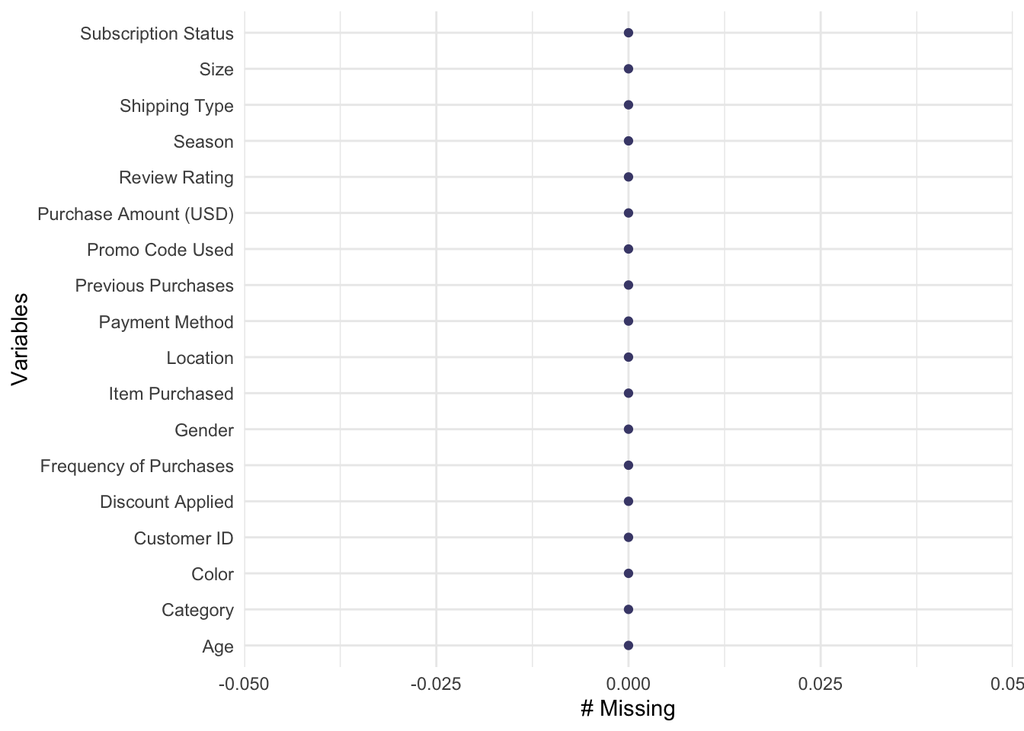

```r
gg_miss_var(data)
```

NA отсутсвуют,поэтому продолжим без последующей фильтрации.

Так как теперь наши данные подготовлены к работе,начнем их визуализировать и изучать.

# Изучение клиентов для определения их предпочтений

Сначала построим столбчатую диаграмму, которая позволит оценить численность людей каждого пола в общей совокупности покупателей.

## График 1. Распределение клиентов по полу

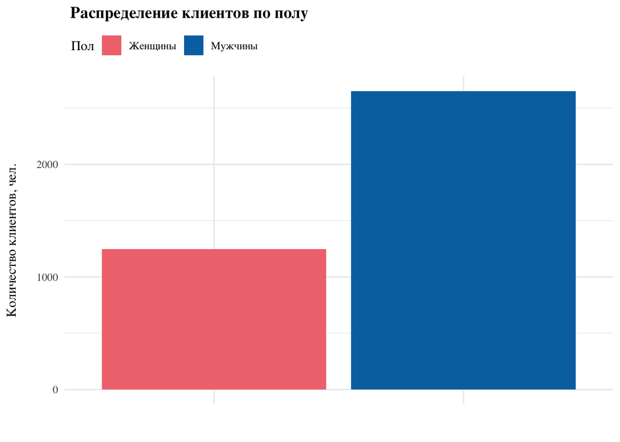

```r
data$Gender <- factor(data$Gender,
                        levels = c("Female", "Male"),
                        labels = c("Женщины", "Мужчины"))

ggplot(data, aes(x = Gender, fill = Gender)) +
  geom_bar() +
  scale_fill_manual(values = c("#F0777D", "#0072B2")) +
  labs(title = "Распределение клиентов по полу",
       x = " ",
       y = "Количество клиентов, чел.\n",
       fill = "Пол") +
  scale_x_discrete(labels = c("male" = "мужчины", "female" = "женщины")) +
  theme_minimal() +
  theme(plot.title = element_text(hjust = 0.02, family = "serif", face = "bold"),
        legend.justification="left", legend.position = "top",
        axis.text.x = element_text(color = "white", family = "serif"),
        axis.text.y = element_text(family = "serif"),
        legend.title = element_text(family = "serif"),
        legend.text = element_text(family = "serif"),
        axis.text = element_text(family = "serif"),
        axis.title = element_text(family = "serif"))
```

Из данного графика мы видим, что большая часть клиентов данного магазина - мужчины. Эти данные позволят начать формировать видение целевой аудитории.

Теперь посмотрим на возрастную характеристику покупателей.

## График 2. Распределение возраста клиентов в зависимости от пола

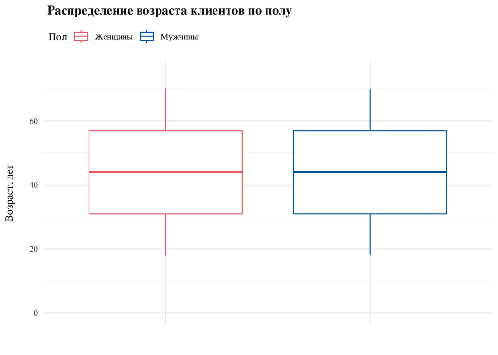

```r
ggplot(data, aes(x = Gender, y = Age, color = Gender)) +
  scale_y_continuous(limits = c(0, max(data$`Age`+5))) +
  geom_boxplot() +
  scale_color_manual(name = "Пол", values = c("#F0777D", "#0072B2")) +
  labs(title = "Распределение возраста клиентов по полу",
       x = " ",
       y = "Возраст, лет\n") +
  theme_minimal() +
  theme(plot.title = element_text(hjust = 0.02, family = "serif", face = "bold"),
        legend.justification="left", legend.position = "top",
        axis.text.x = element_text(color = "white", family = "serif"),
        axis.text.y = element_text(family = "serif"),
        legend.title = element_text(family = "serif"),
        legend.text = element_text(family = "serif"),
        axis.title = element_text(family = "serif"))
```

Данный график хорошо иллюстрирует, что возраст мужчин и женщин в магазине одинаковый. Также мы видим, что возраст большей части ЦА представлен в примерном диапазоне от 31 года до 57 лет.

Чтобы лучше понимать потребности целевой аудитории, визуализируем разбиение покупаемых товаров по категориям.

## График 3. Распределение товаров по категориям

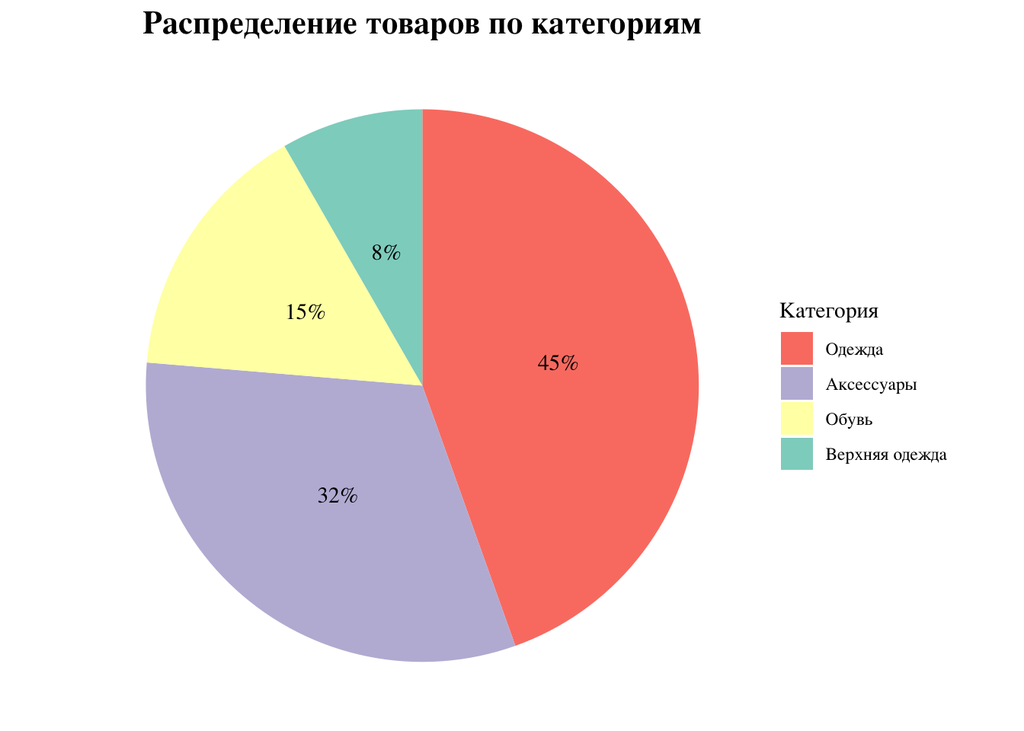

```r
library(ggplot2)

data_gr <- data %>%
  count(Category) %>%
  mutate(Category = case_when(
    Category == "Accessories" ~ "Аксессуары",
    Category == "Clothing" ~ "Одежда",
    Category == "Footwear" ~ "Обувь",
    Category == "Outerwear" ~ "Верхняя одежда"
  )) %>%
  arrange(desc(n)) %>%
  mutate(Category = factor(Category, levels = rev(Category)))


ggplot(data = data_gr, aes(x = "", y = n, fill = Category)) +
  geom_bar(stat = "identity", width = 1) +
  coord_polar("y", start = 0) +
  geom_text(aes(label = paste0(round((n/sum(n))*100), "%")), position = position_stack(vjust = 0.5), family = "serif") +
  labs(title = "Распределение товаров по категориям",
       fill = "Категория") +
  theme_void() +
  theme(legend.position = "right",
        legend.text = element_text(family = "serif"),
        legend.title = element_text(family = "serif"),
        plot.title = element_text(family = "serif", face = "bold", size = 16, hjust = 0.5)) +
  scale_fill_brewer(palette = "Set3", guide = guide_legend(reverse = TRUE))
```

Далее проанализируем влияние возрастного фактора на статус подписки покупателя.

## График 4.Распределение групп потребителей по возрасту и статусу подписки

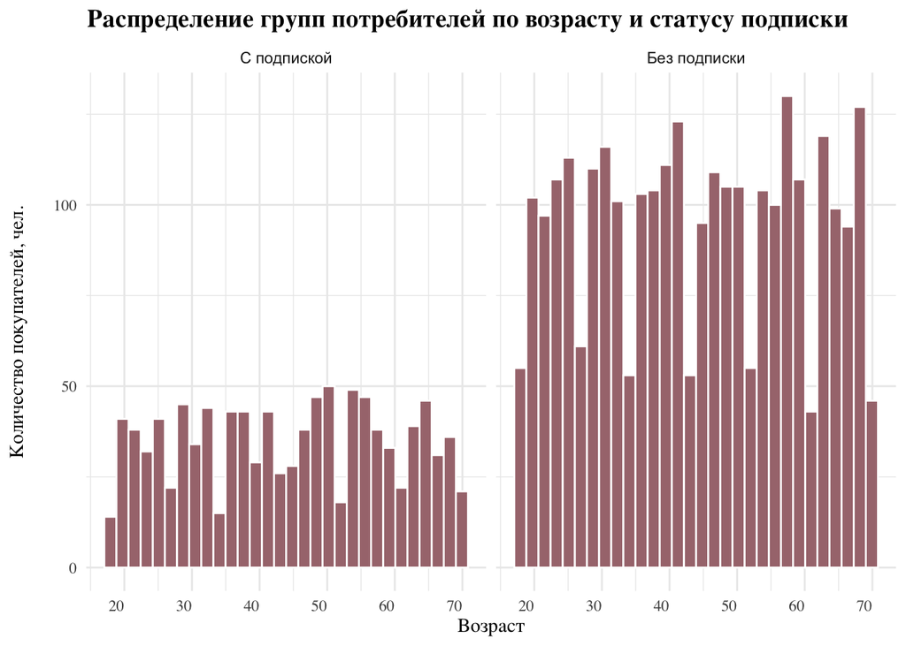

```r
la <- c(`TRUE` = "С подпиской",
        `FALSE` = "Без подписки")
ggplot(data, aes(x=`Age`))+
  geom_histogram(color = "white", fill = "#A8777D") +
  facet_wrap(~ `Subscription Status`, labeller = labeller(`Subscription Status` = la) ) +
  labs(
    title = "Распределение групп потребителей по возрасту и статусу подписки",
    y = "Количество покупателей, чел.\n",
    x = "Возраст"
  ) +
  theme_minimal() +
  theme(
    axis.text.x = element_text(hjust = 1, family = "serif"),
    axis.text.y = element_text(family = "serif"),
    axis.title = element_text(hjust = 0.5, family = "serif"),
    plot.title = element_text(hjust = 0.03, size = 14, face = "bold", family = "serif"),
    strip.text.y = element_text(size = 14, margin = margin(r = 10, l = 10), family = "serif"),
    legend.title = element_text(family = "serif"),
    legend.text = element_text(family = "serif")
  )
```

# Общие выводы:

Таким образом, можно сделать вывод, что основная масса покупателей магазина - мужчины,однако женщины также посещают данный магазин. Возраст мужчин и женщин преимущественно совпадает, находясь в диапозоне от 31 года до 57 лет. У покупателей наиболее выражена потребность в товарах из категории Одежда, так как число покупок товаров именно этой категории превалирует над остальными. Достаточно интересной характеристикой покупателей этого магазина является то, что лишь треть из них имеет активную подписку в магазине, это говорит о том, что лишь часть покупателей является достаточно лояльной и наиболее заинтересованной.